# Metaheurystyki i Technologie Wieloagentowe - Lab1

## Basic Information

### Contact information:

*Bartłomiej Twardowski*

B.Twardowski@ii.pw.edu.pl @btwardow

### Metaheurystyki i technologie wieloagentowe

- Lab 1 - 26/10/2014
- Lab 2 - 14/12/2014
- Lab 3 - 01/02/2014
- Lab e-learning

## Running RStudio Server

1. Na komputerze w trybie logowania w dolnej lewej części ekranu klikamy pozycję Session i wybieramy GNOME
2. Logujemy się za pomocą następujących poświadczeń:
- użytkownik: test
- hasło: test2012
1. W lewym górnym rogu z pozycji Applications wybieramy przeglądarkę internetową klikając kolejno Internet->IceWeasel.
2. W polu adresu wpisujemy r2d2.ii.pw.edu.pl:8787
3. Pojawia się ekran logowania do środowiska RStudio. Wpisujemy poświadczenia z serwera galera.

## Agenda

- Gradient Descent
  - Outline
  - Algorithm Intuition
  - Solving linear regression problem
- Single-State Metaheuristic
  - Main Framework
  - Hill-Climbing
- Population Methods - Evolutionary Algorithms

## Slides and source code

Presentation, exercise source code with solutions are available online at:

- http://home.elka.pw.edu.pl/~btwardow/MTW_lab_gd.zip
- https://github.com/btwardow/metaheuristic

## Gradient Descent - Intro

- sometimes called Gradient Ascent when we maxmize cost function (e.g. in book "Essentials of Metaheuristics")
- There is some cost function: \(J(\theta)\)
- Goal: \(\min_{\theta} J(\theta)\)

### Algorithm:

- Start with some \(\theta\)
- Keep changing \(\theta\) to reduce \(J(\theta)\) until we hopefully end up at minimum

## Gradient Descent - Intuition

Let's make some experiments!

Script in: `exercises/grad_desc_animation.R`

```r
library(animation)
par(mar = c(4, 4, 2, 0.1))
grad.desc(interact = TRUE, gamma = 0.1)
```

Harder example:

```r
ani.options(nmax = 70)
par(mar = c(4, 4, 2, 0.1))
f2 = function(x, y) sin(1/2 * x^2 - 1/4 * y^2 + 3) *
  cos(2 * x + 1 - exp(y))
grad.desc(f2, c(-2, -2, 2, 2), c(-1, 0.5),
          gamma = 0.3, tol = 1e-04, interact = TRUE)
```

## Simple Implementation of Linear Regression by Gradient Descent in R

```r
gradient_descent <- function(X, y, init_theta, cost_f = cost_fun,
                             alpha = 0.01 , num_iters = 1000) {
  cost_h <- double(num_iters) #history
  theta_h <- list(num_iters) #history
  theta <- init_theta
  X <- cbind(1, matrix(X))
  for (i in 1:num_iters) {
    error <- (X %*% theta - y)
    delta <- t(X) %*% error / length(y) #gradient calc.
    theta <- theta - alpha * delta # update step
    cost_h[i] <- cost_fun(X, y, theta) #save history
    theta_h[[i]] <- theta #save history
  }
  return(list(theta=theta_h[[num_iters]], cost=cost_h[num_iters],
              theta_history=theta_h, cost_history=cost_h))
}
```

## Exercise 1: cars dataset

Script in: `exercises/lin_regression_by_grad_desc.R`

- Load dataset and change: miles to kilometers and feet to meters
- Plot data
- Try another dataset analysis function and visualization

```r
require(datasets)
head(cars)
```

```
##   speed dist
## 1     4    2
## 2     4   10
## 3     7    4
## 4     7   22
## 5     8   16
## 6     9   10
```

## Exercise 1: cars dataset - plot

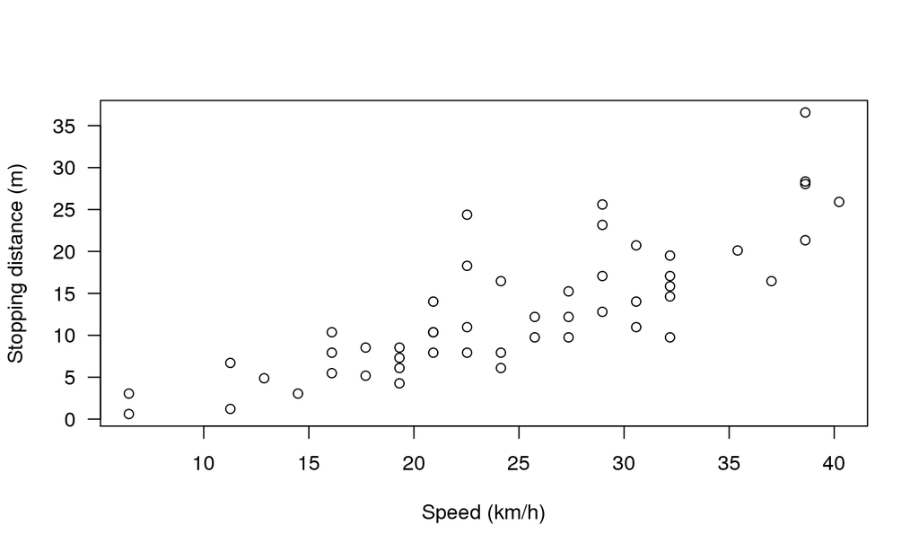

## Exercise 2: Running GD on cars dataset

- Implement cost function for linear regression
- Run `gradient_descent()` function on cars dataset and save to variable `gd_result`

## Exercise 2: Running GD on cars dataset (Solution)

```r
cost_fun <- function(X, y, theta) {
  sum( (X %*% theta - y)^2 ) / (2*length(y))
}
```

```r
theta_init <- matrix(c(0,0), nrow=2)
iterations <- 100
gd_result <- gradient_descent(X = cars$speed,
                              y = cars$dist,
                              cost_f = cost_fun,
                              init_theta = theta_init,
                              alpha = 0.0001,
                              num_iters = iterations
)
```

## Gradient Descent - Comparing to *lm()*

- in R: lm() linear model
- function can be used to create a simple regression model
- parameters: – formula: describe the modes, e.g. "Y ~ X", where Y is dependent(predicted) variable and X is independent variable – data: variable containing dataset

## Gradient Descent - Comparing to *lm()* #1

```r
lm1 = lm(dist~speed, cars)
lm1
```

```
##
## Call:
## lm(formula = dist ~ speed, data = cars)
##
## Coefficients:
## (Intercept)        speed
##     -5.3581       0.7448
```

## Gradient Descent - Comparing to *lm()* #2

[figure not shown]

```r
predict_speed <- data.frame(speed = c(80, 100, 120))
predict_dist <- predict(lm1, predict_speed)
```

## Gradient Descent - Real Life

- usefull tool for convex function optimization
- we not use presented approach for production data - it's far too slow :-)
- for large datasets (BigData use cases) use implementation like: Stocastic Gradient Descent (SGD) available in: Spark MLib, Mahout, H2O
  - e.g. collaborative filltering matrix factorization

## Single-State Metaheuristic - Framework

```r
metaheuristic <- function(X, y, S_init,
                          quality, tweek,
                          max_iter = 1000, threshold = 0.00001) {
  i <- 0
  S <- S_init
  repeat {
   i <- i + 1
   R <- tweak(S)
   if(quality(R,X,y) < quality(S,X,y))
     S <- R
   if(quality(S,X,y) <= threshold || i == max_iter)
     break
  }
  S
}
```

## Exercise 3 - Hill-Climbing

Script in: `exercises/metah_single_state.R`

## Exercise 3 - Example Solution

```r
quality <- function(S, X, y)
  sum((y - X %*% S)^2)

tweak <- function(S) {
  S + runif(nrow(S), min=-0.1, max=0.1)
}
```

```r
S_init <- matrix(c(0,0), nrow=2)
X <- cbind(1, matrix(cars$speed_km))
y <- cars$dist_m
iterations <- 1000
result <- metaheuristic(X, y, S_init, quality, tweek, iterations)
```

## Exercise 3 - Explore vs Exploit

See *Harder Example* in script: `exercises/metah_single_state.R`

- Try to implement Hill-Climbing with Random Restarts and visualize it on contour plot

## Intro to Population Methods in R

- There are many packages:
  - NMOF
  - DEoptim
  - cmaes
  - GA
  - genalg
  - pso
  - …and many others…

## Example: Particle Swarm Optimization

```r
#install.packages('pso')
require('pso')
?psoptim
```

- Run example from help